# STA261 Summer 2018 Lecture 1:

Central Limit Theorem for Round-off Error

Alex Stringer

2018-05-28

```r
# Load the tidyverse packages
suppressMessages({
  suppressWarnings({
    library(tidyverse)
  })
})
```

In class, we discussed the Central Limit Theorem, regarding the distribution of sums of independent random variables with zero mean and finite variance. Here we provide a computational example to illustrate this concept.

We expand on Question 12 from Chapter 5 of Rice, page 189. Suppose we are adding together a bunch of numbers $x_{i}$, each of which are stored to many decimal places. We want the result of our adding to be an integer, which means we have to round to zero decimal places. Do we round each number and then sum them, or do we sum them and then round the result? Intuitively we might think that there would be less error in rounding once than rounding many times. What do you think? Let’s investigate.

The rounding error when rounding any number to zero decimal places can be modelled by a $Unif(-0.5,0.5)$ random variable. We can argue this heuristically, or we can simulate and verify empirically:

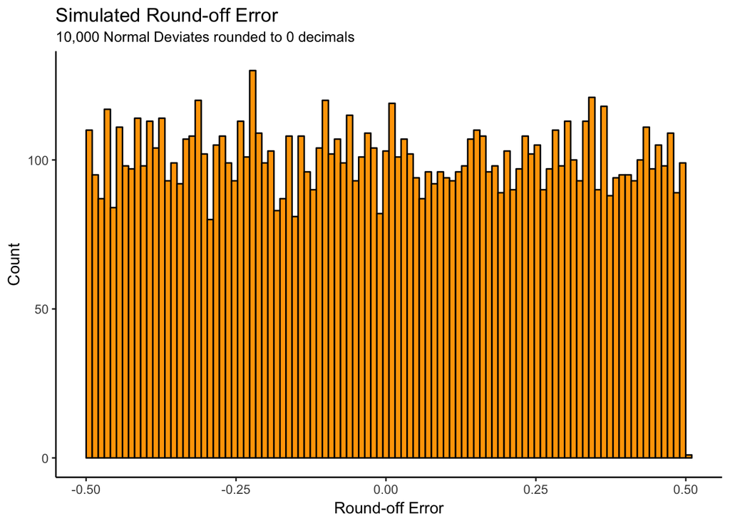

```r
# Generate a bunch of numbers, it doesn't matter from what distribution
x <- rnorm(10000)
# Round them
y <- round(x)
# Compute the roundoff error
u <- x - y
# Histogram
data_frame(x = u) %>%
  ggplot(aes(x = x)) +
  theme_classic() +
  geom_histogram(bins = 100,fill = "orange",colour = "black") +
  labs(title = "Simulated Round-off Error",
       subtitle = "10,000 Normal Deviates rounded to 0 decimals",
       x = "Round-off Error",
       y = "Count")
```

The approximation seems reasonable. We can test this further using a Quantile-Quantile plot: a plot of the *sample* quantiles against the *theoretical* quantiles of the distribution of interest, i.e. a $Unif(-0.5,0.5)$:

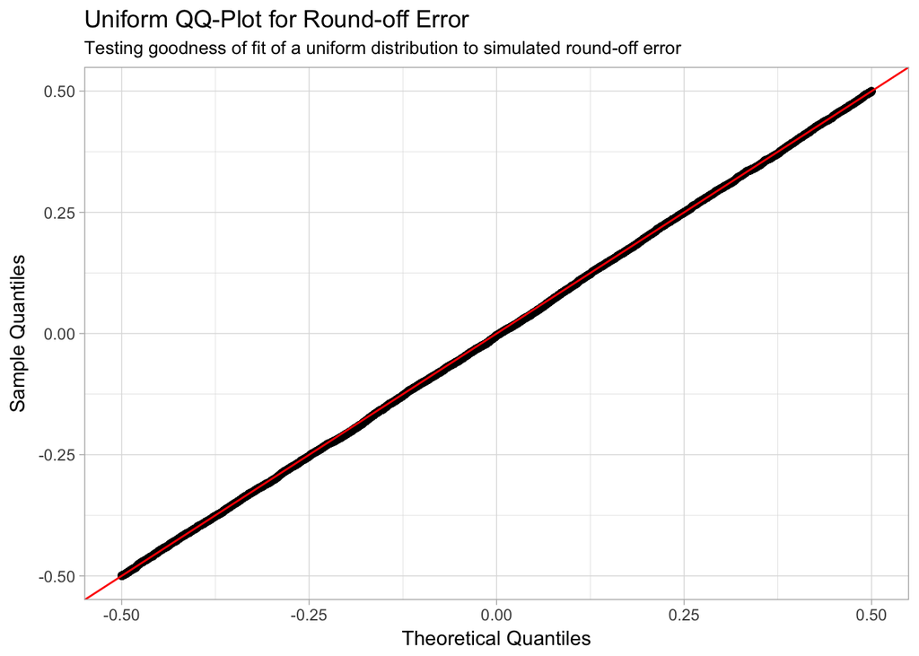

```r
data_frame(x = u) %>%
  arrange(x) %>%
  mutate(q = qunif(1:length(u) / (1 + length(u)),min = -0.5,max = 0.5)) %>%
  ggplot(aes(x = q,y = x)) +
  theme_light() +
  geom_point() +
  geom_abline(slope = 1,intercept = 0,colour = "red") +
  labs(title = "Uniform QQ-Plot for Round-off Error",
       subtitle = "Testing goodness of fit of a uniform distribution to simulated round-off error",
       x = "Theoretical Quantiles",
       y = "Sample Quantiles")
```

This indicates nearly perfect fit.

We proceed assuming that roundoff error is uniformly distributed on $(-0.5,0.5)$.

Letting $y_{i}$ denote the rounded $x_{i}$, we have
$$x_{i} = y_{i} + u_{i}$$
where $u_{i} \sim Unif(-0.5,0.5)$ is the roundoff error. The sum, then, can be expressed as
$$\sum_{i=1}^{n} x_{i} = \sum_{i=1}^{n}y_{i} + \sum_{i=1}^{n}u_{i}$$
As the rounding of each number is independent, $S_{n} = \sum_{i=1}^{n}u_{i}$ is a sum of independent random variables. We find
$$\begin{aligned}
E(S_{n}) &= \sum_{i=1}^{n}E(u_{i}) = 0 \\
Var(S_{n}) &= \sum_{i=1}^{n} Var(u_{i}) = \sum_{i=1}^{n} \frac{(0.5 - (-0.5))^{2}}{12} = n/12
\end{aligned}$$
Applying the CLT lets us approximate the distribution of $S_{n}$:
$$\frac{S_{n} - 0}{\sqrt{n/12}} \overset{\cdot}{\sim} N(0,1)$$
Or, put another way,
$$S_{n} \overset{\cdot}{\sim} N(0,n/12)$$
So the total roundoff error when rounding each summand before summing is approximately $N(0,n/12)$ distributed, when the number of summands $n$ is reasonably large.

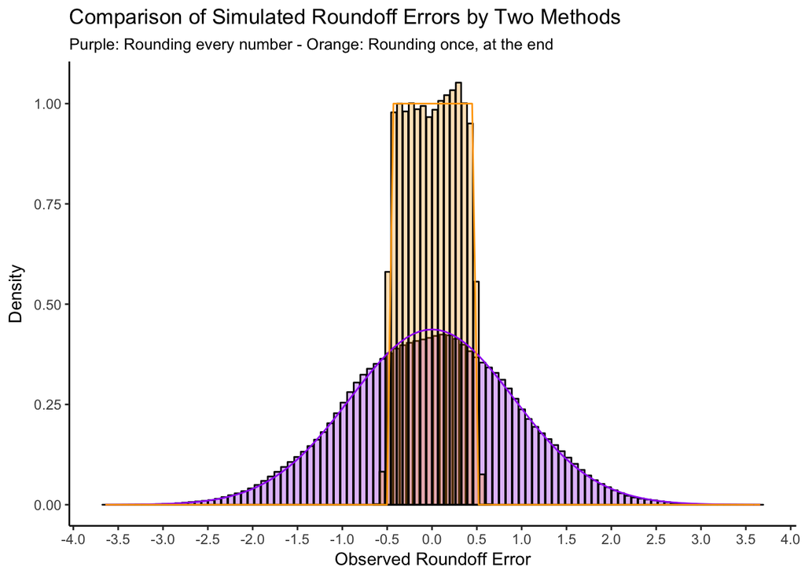

```r
set.seed(4578)
n <- 10
B <- 10000 # number of simulations to do
roundoffs_1 <- numeric(B)
roundoffs_2 <- numeric(B)
for (b in 1:B) {
  # Generate the n random numbers
  x <- rnorm(n)
  # Compute the two roundoff errors
  roundoffs_1[b] <- sum(x - round(x))
  roundoffs_2[b] <- sum(x) - round(sum(x))
}

# Plot them on the same graph
data_frame(round_many_x = density(roundoffs_1,n=100)$x,
           round_many_y = density(roundoffs_1,n=100)$y
           ) %>%
  ggplot() +
  theme_classic() +
  geom_bar(aes(x = round_many_x,y = round_many_y),stat = "identity",colour = "black",fill = "purple",alpha = 0.3) +
  geom_bar(data = data_frame(round_once_x = density(roundoffs_2,n=20)$x,
                             round_once_y = density(roundoffs_2,n=20)$y),
           mapping = aes(x = round_once_x,y = round_once_y),
           stat = "identity",
           colour = "black",
           fill = "orange",
           alpha = 0.3) +
  stat_function(fun = dnorm,args = list(mean = 0,sd = sqrt(n/12)),colour = "purple") +
  stat_function(fun = dunif,args = list(min = -.5,max = .5),colour = "orange") +
  scale_x_continuous(breaks = seq(-4,4,by = 0.5)) +
  labs(title = "Comparison of Simulated Roundoff Errors by Two Methods",
       subtitle = "Purple: Rounding every number - Orange: Rounding once, at the end",
       x = "Observed Roundoff Error",
       y = "Density")
```

We see two things: the central limit theorem applies very well in this case even when $n = 10$; and rounding once at the end is almost certainly a better strategy than rounding every number before summing! We can see this analytically as well; while both strategies have the same *expected* roundoff error, the error when rounding every summand has a higher variance for any $n > 1$, and is technically unbounded, where as the error from rounding once must necessarily be bounded on $(-0.5,0.5)$.